# Marani et al. trends investigation

Joshua Blake

## Dataset

```r
library(poweRlaw)
library(fitdistrplus)
library(Pareto)
library(ggplot2)
library(dplyr)
library(tidyr)

# Read in data from excel
all_data = readxl::read_excel("all-epidemics.xlsx", n_max = 540) |>
    dplyr::select(!starts_with("...")) |>
    bind_rows(tribble(
        ~Location, ~`Start Year`, ~`End Year`, ~`# deaths (thousands)`, ~`World Population (thousands)`, ~Disease,
        "HIV/AIDS", 1981, 2022, 40e3, 4.61e6, "AIDS", # Estimated deaths to end 2022
        "COVID-19", 2020, 2022, 20e3, 7.84e6, "Coronavirus", # Excess deaths to end 2022
    )) |>
    mutate(
        start = `Start Year`,
        length = `End Year` - `Start Year` + 1,
        intensity = `Intensity (deaths per mil/year)` / 1000,
        intensity2 = `# deaths (thousands)` / (`World Population (thousands)` * length),
        prop_dead = `# deaths (thousands)` / `World Population (thousands)`,
    )
glimpse(all_data)
```

```
## Rows: 541
## Columns: 15
## $ Location                           <chr> "China, Kwangsi", "China, Shansi", …
## $ `Start Year`                       <dbl> 1500, 1504, 1506, 1507, 1510, 1511,…
## $ `End Year`                         <dbl> 1500, 1504, 1506, 1541, 1510, 1511,…
## $ `# deaths (thousands)`             <dbl> -999.0, -999.0, -999.0, 300.0, -999…
## $ `World Population (thousands)`     <dbl> 463230, 463230, 463230, 463230, 463…
## $ `Relative Epidemic size (per mil)` <dbl> -2.156596075, -2.156596075, -2.1565…
## $ `Intensity (deaths per mil/year)`  <dbl> -2.156596075, -2.156596075, -2.1565…
## $ Disease                            <chr> "Unknown", "Unknown", "Unknown", "S…
## $ References                         <chr> "McNeill, 1998", "McNeill, 1998", "…
## $ Notes                              <chr> NA, NA, NA, NA, NA, NA, NA, NA, NA,…
## $ start                              <dbl> 1500, 1504, 1506, 1507, 1510, 1511,…
## $ length                             <dbl> 1, 1, 1, 35, 1, 1, 1, 1, 1, 1, 7, 2…
## $ intensity                          <dbl> -2.156596e-03, -2.156596e-03, -2.15…
## $ intensity2                         <dbl> -2.156596e-03, -2.156596e-03, -2.15…
## $ prop_dead                          <dbl> -2.156596e-03, -2.156596e-03, -2.15…
```

A total of 541 epidemics are recorded in the dataset. 395 started between 1600 and 1944.

## Notes on dataset construction

- inclusion criteria
  - Independence: epidemic cannot end in the same year that marks the start of a subsequent epidemic of the same disease, irrespective of their occurrence location.
    - Epidemics recorded in the literature that occurred in the same period of time were merged into a single epidemic (e.g., several plague events in Europe in the 17th and 18th centuries). This first independence condition ensures that the analyses only focus on epidemics associated with a new or reemerging pathogen after a previous epidemic has ended in the human population (e.g., due to the reemergence of zoonoses from a natural reservoir).
  - only non-active epidemic included
  - if ended by introducing vaccines or treatments then excluded
- possible European bias
  - the worst pandemics listed seem to be quite heavily European, with Asia underrepresented in particular
  - but also better data collection in Europe
  - and some Euro-centric source (specifically V. Harding, “The Dead and the Living in Paris and London, 1500–1670”)

## Classifying diseases

This could really do with someone else looking over it.

```r
classify_transmission = function(disease) {
    disease = case_when(
        stringr::str_starts(disease, "Typhus") ~ "Typhus",
        stringr::str_starts(disease, "Smallpox") ~ "Smallpox",
        .default = disease
    )
    case_match(
        disease,
        c("Tuberculosis", "Encephalitis", "Smallpox", "Influenza", "Coronavirus", "Measles", "Pneumonia", "Whooping Cough", "Diphtheria", "Meningitis", "Rubella", "Scarlet Fever") ~ "Respiratory",
        c("Dengue", "Plague", "Typhus", "Yellow Fever", "Sleeping Sickness", "Visceral Leishmaniasis", "Relapsing fever") ~ "Vector",
        c("Polio", "Cholera", "Dysentery", "Cocolitzli", "Typhoid") ~ "Fecal-oral",
        c("AIDS", "Ebola", "Hemorragic Fever") ~ "Bodily fluids",
    )
}
```

## Data exploration

### Failed non-linear Fitting

```r
# fit dataset with a poisson regression model
# predict number of pandemics per year
# use a spline with 5 degrees of freedom
data_for_fit = all_data |>
    count(start) |>
    complete(start = 1500:2019, fill = list(n = 0))
fit = glm(n ~ splines::ns(start, df = 5), data = data_for_fit, family = "poisson")

# plot fit and data with prediction interval
ggplot(data_for_fit, aes(start, n)) +
    geom_line(aes(y = predict(fit, data_for_fit, type = "response")), colour = "red") +
    geom_point() +
    geom_ribbon(
        aes(ymin = predict(fit, data_for_fit, type = "response", se.fit = TRUE)$fit - 1.96 * predict(fit, data_for_fit, type = "response", se.fit = TRUE)$se.fit,
            ymax = predict(fit, data_for_fit, type = "response", se.fit = TRUE)$fit + 1.96 * predict(fit, data_for_fit, type = "response", se.fit = TRUE)$se.fit),
        fill = "grey", alpha = 0.5
    ) #+
    scale_y_log10()

all_data |>
    mutate(
        decade = floor(start / 10) * 10,
    ) |>
    count(decade) |>
    filter(decade <= 1950) |>
    ggplot(aes(decade, n)) +
    geom_line() +
    geom_point() +
    # best fit line with poisson regression
    geom_smooth(
        method = "glm",
        method.args = list(family = "poisson")
    )
```

[output not shown]

### Overall trend, by choice of threshold

- Below changes the min threshold for inclusion
- Possible the least bad pandemics are being better recorded since 1900

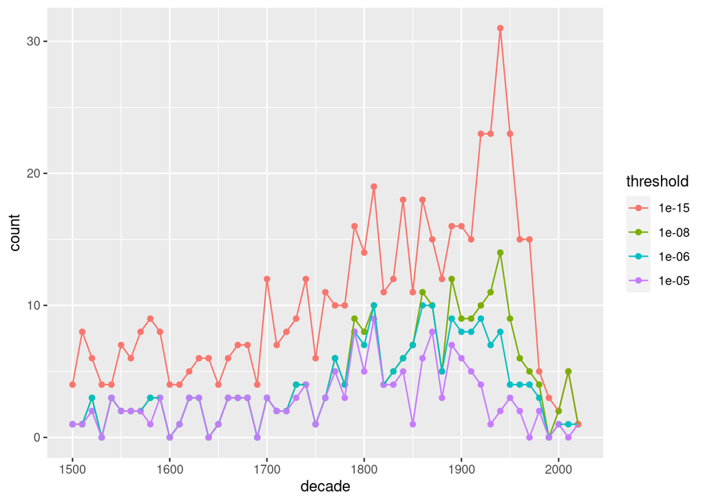

```r
thresholds = 10^c(-5,-6,-8,-15)
all_data |>
    mutate(
        decade = floor(start / 10) * 10,
        `# deaths (thousands)` = pmax(`# deaths (thousands)`, 1e-3),
        prop_dead = `# deaths (thousands)` / `World Population (thousands)`,
    ) |>
    reframe(
        threshold = thresholds,
        count = purrr::map_dbl(thresholds, ~sum(prop_dead >= .x)),
        .by = decade
    ) |>
    # put 0 for threshold / decade combination if missing
    complete(decade = seq(from = 1500, to = 2019, by = 10), threshold, fill = list(count = 0)) |>
    mutate(threshold = as.factor(threshold)) |>
    ggplot(aes(x = decade, y = count, colour = threshold)) +
    geom_point() +
    geom_line()
```

## Growth in diseases

### Looks exponential

- Doubling time: ~190 years
- Corresponds with general growth in many metrics

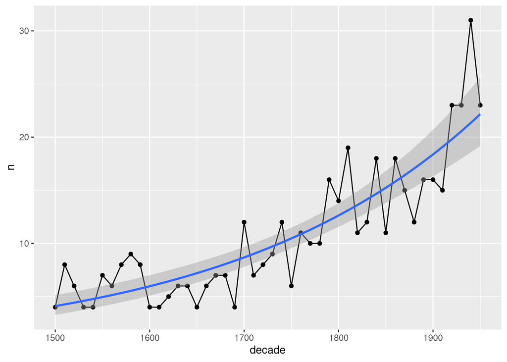

```r
all_data |>
    mutate(
        decade = floor(start / 10) * 10,
    ) |>
    count(decade) |>
    filter(decade <= 1950) |>
    ggplot(aes(decade, n)) +
    geom_line() +
    geom_point() +
    # best fit line with poisson regression
    geom_smooth(method = "glm", method.args = list(family = "poisson"))
```

### Dominanted by respiratory

- Caveat: early causes often unknown
- Doubling time: ~100 years

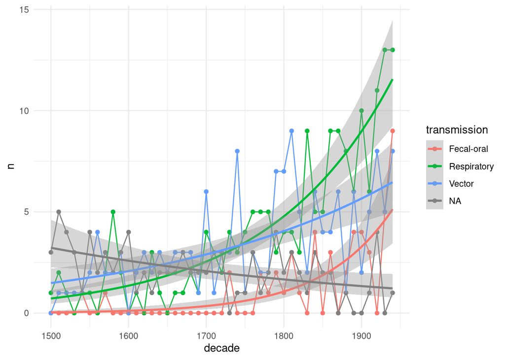

```r
all_data |>
    # filter(prop_dead > 1e-6, start >= 1600) |>
    mutate(transmission = classify_transmission(Disease)) |>
    count(decade = floor(start / 10) * 10, transmission) |>
    filter(decade < 1950) |>
    # filter(is.na(transmission)) |>
    # count(Disease)
    # pivot_wider(names_from = transmission, values_from = n) |>
    # print(n=Inf)
    complete(decade = seq(from = 1500, to = 1945, by = 10), transmission, fill = list(n = 0)) |>
    ggplot(aes(x = decade, y = n, colour = transmission)) +
    geom_point() +
    geom_line() +
    # poisson regression
    geom_smooth(method = "glm", method.args = list(family = "poisson")) +
    theme_minimal()
```

### Only worst diseases

Threshold at 1 in 100,000 of the population killed. 80,000 deaths today or 10,000 in 1800.

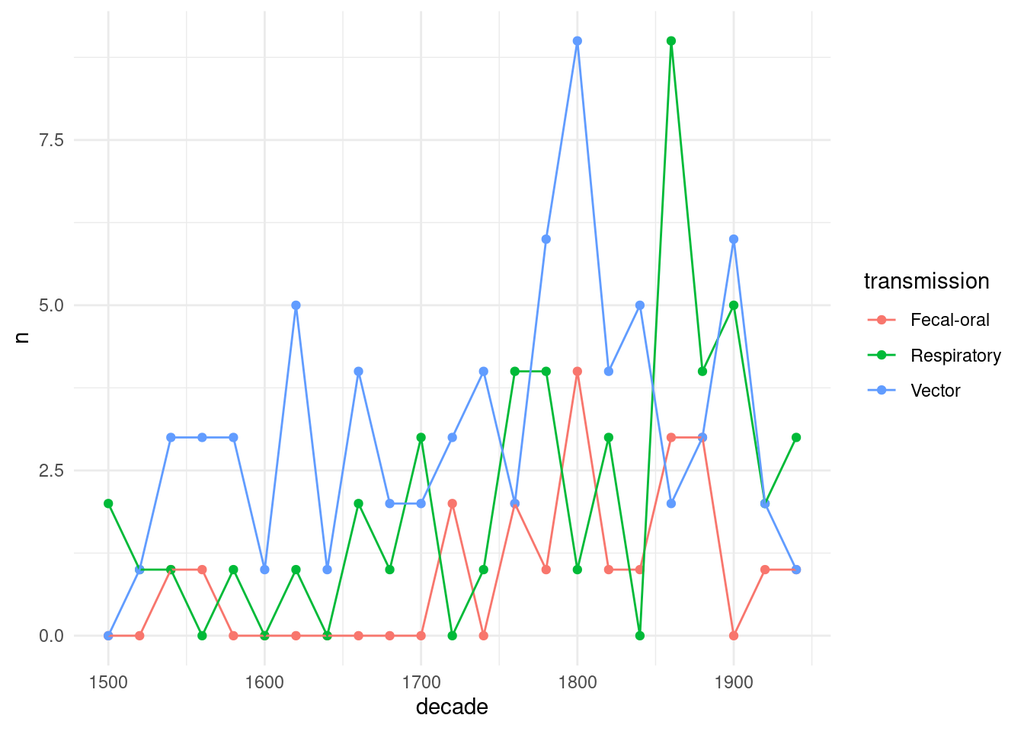

```r
all_data |>
    filter(prop_dead > 1e-5) |>
    mutate(transmission = classify_transmission(Disease)) |>
    count(decade = floor(start / 20) * 20, transmission) |>
    filter(decade < 1950) |>
    # filter(is.na(transmission)) |>
    # count(Disease)
    # pivot_wider(names_from = transmission, values_from = n) |>
    # print(n=Inf)
    complete(decade = seq(from = 1500, to = 1945, by = 20), transmission, fill = list(n = 0)) |>
    ggplot(aes(x = decade, y = n, colour = transmission)) +
    geom_point() +
    geom_line() +
    # poisson regression
    # geom_smooth(method = "glm", method.args = list(family = "quasipoisson")) +
    theme_minimal()
```

Big thing is vector born diseases around 1800. Lets look at those.

```r
all_data |>
    mutate(transmission = classify_transmission(Disease)) |>
    filter(
        prop_dead > 1e-5,
        transmission == "Vector",
        between(start, 1780, 1840),
    ) |>
    DT::datatable()
```

|  | Location | Start Year | End Year | # deaths (thousands) | World Population (thousands) | Relative Epidemic size (per mil) | Intensity (deaths per mil/year) | Disease | References | Notes | start | length | intensity | intensity2 | prop_dead | transmission |
| --- | --- | --- | --- | --- | --- | --- | --- | --- | --- | --- | --- | --- | --- | --- | --- | --- |
| 1 | Dalmatia, Tunisia, Egypt | 1783 | 1795 | 321 | 877120 | 0.3659704487413353 | 0.02815157298010271 | Plague | Kohn, 1999; Valensi 1969; https://en.wikipedia.org/wiki/Second_plague_pandemic | Sum of Dalmatia from Kohn (1999), Tunisia 1784-1785 from Valensi (1969) and Egypt from https://en.wikipedia.org/wiki/Second_plague_pandemic | 1783 | 13 | 2.815157298010271e-05 | 2.815157298010271e-05 | 0.0003659704487413353 | Vector |
| 2 | Haiti Yellow Fever | 1790 | 1802 | 27 | 902600 | 0.02991358298249501 | 0.002301044844807309 | Yellow Fever | https://en.wikipedia.org/wiki/History_of_yellow_fever |  | 1790 | 13 | 2.301044844807308e-06 | 2.301044844807309e-06 | 2.991358298249502e-05 | Vector |
| 3 | Philadelphia | 1793 | 1793 | 11 | 913520 | 0.01204133461774236 | 0.01204133461774236 | Yellow Fever | https://www.historyofvaccines.org/content/yellow-fever-decimates-philadelphia |  | 1793 | 1 | 1.204133461774236e-05 | 1.204133461774236e-05 | 1.204133461774236e-05 | Vector |
| 4 | West Indies | 1795 | 1795 | 31 | 920800 | 0.03366637706342311 | 0.03366637706342311 | Yellow Fever | Vainio and Cutts, 1998 |  | 1795 | 1 | 3.366637706342311e-05 | 3.366637706342311e-05 | 3.366637706342311e-05 | Vector |
| 5 | Italy | 1796 | 1800 | 20 | 924440 | 0.02163471939768941 | 0.004326943879537882 | Typhus | Kohn, 1999 |  | 1796 | 5 | 4.326943879537882e-06 | 4.326943879537882e-06 | 2.163471939768941e-05 | Vector |
| 6 | Cairo, Diyarkbar, Mosul, Baghdad | 1798 | 1801 | 59 | 931720 | 0.06332374533121539 | 0.01583093633280385 | Plague | Issawi, 1988; Russell and Russell, 2003 | Diyarkbar, Mosul, Baghdad 1799-1800 (38k deaths) from Issawi (1988), Egypt from Russell and Russell (2003) | 1798 | 4 | 1.583093633280385e-05 | 1.583093633280385e-05 | 6.332374533121538e-05 | Vector |
| 7 | Haiti | 1802 | 1803 | 40 | 949300 | 0.04213631096597493 | 0.02106815548298746 | Yellow Fever | Kohn, 1999 |  | 1802 | 2 | 2.106815548298746e-05 | 2.106815548298746e-05 | 4.213631096597493e-05 | Vector |
| 8 | Spain | 1803 | 1805 | 27 | 954450 | 0.02828854314002829 | 0.009429514380009428 | Yellow Fever | Kohn, 1999 |  | 1803 | 3 | 9.429514380009428e-06 | 9.42951438000943e-06 | 2.828854314002829e-05 | Vector |
| 9 | Austria and Prussia | 1805 | 1807 | 10 | 964750 | 0.01036537963202902 | 0.003455126544009674 | Typhus | Kohn, 1999 | &gt; 10k according to source | 1805 | 3 | 3.455126544009674e-06 | 3.455126544009674e-06 | 1.036537963202902e-05 | Vector |
| 10 | Ottoman Empire, Malta | 1812 | 1819 | 365 | 1005950 | 0.3628410954818828 | 0.04535513693523535 | Plague | Mangion 2013 |  | 1812 | 8 | 4.535513693523535e-05 | 4.535513693523535e-05 | 0.0003628410954818828 | Vector |

[output cut: 9 more lines]

## Shrink in diseases

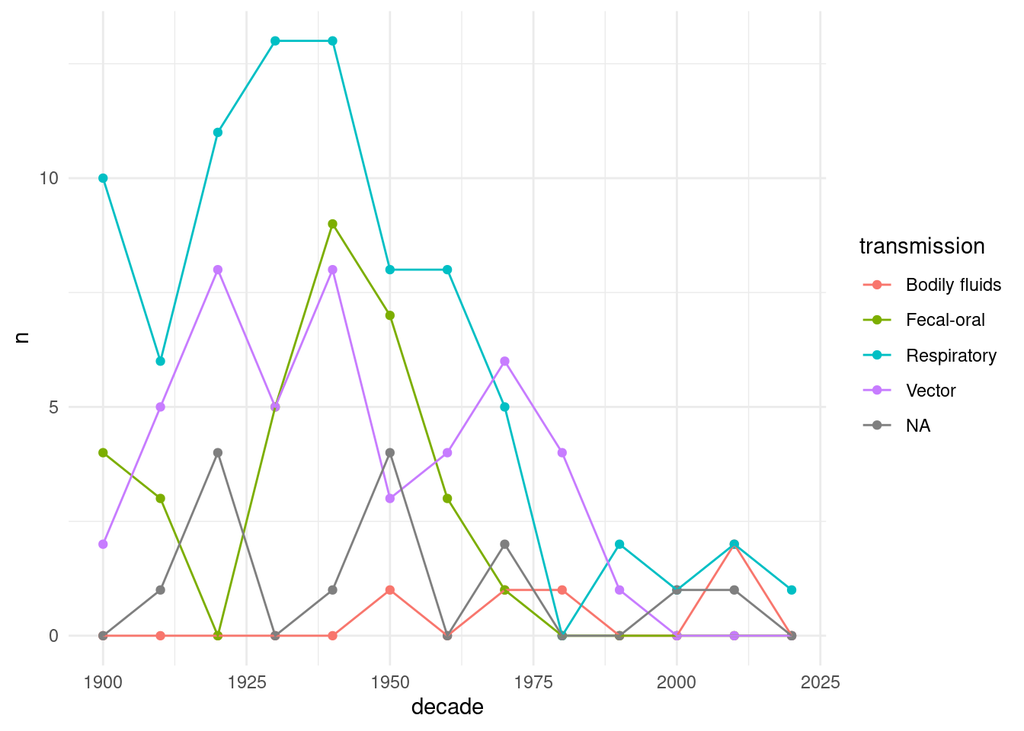

```r
all_data |>
    mutate(transmission = classify_transmission(Disease)) |>
    count(decade = floor(start / 10) * 10, transmission) |>
    filter(decade >= 1900) |>
    complete(decade = seq(from = 1900, to = 2020, by = 10), transmission, fill = list(n = 0)) |>
    ggplot(aes(x = decade, y = n, colour = transmission)) +
    geom_point() +
    geom_line() +
    # poisson regression
    # geom_smooth(method = "glm", method.args = list(family = "poisson")) +
    theme_minimal()
```